# H1c & H1d: Discriminant Validity and Structural Consistency

Author

Caroline Müller

Published

May 7, 2026

Analyses for H1c (discriminant validity) and H1d (structural consistency of inter-need patterns). Loads the pre-processed per-condition dataset exported by `10_Analyses_RQ2.qmd` — all exclusions and repeat-aggregations are already applied.

Input: `10_data/80_analyses_exports/d_rq3_ai_conditions.rds`

# 1 Setup

# 2 Data

# 3 H1c: Discriminant Validity

Discriminant validity requires that the LLM score for a given need dimension correlates more strongly with the *matching* questionnaire dimension (r_within) than with *non-matching* dimensions (r_cross).

Because all three correlations share the same sample and a common variable (the LLM score), they are **dependent**. Steiger’s (1980) test for overlapping dependent correlations is used rather than the standard Fisher r-to-z transform (which assumes independence). This deviates from the preregistered test; the deviation is noted here.

Six tests per condition: each of the three LLM dimensions (autonomy, competence, relatedness) is compared against both non-matching questionnaire dimensions. Across 9 conditions, this yields 54 tests in total. All tests are two-tailed. A 95% CI on the r_within − r_cross difference is computed via Fisher z-transformation.

| condition | llm_dim | comparison | r_within | r_cross | diff | ci_lo | ci_hi | steiger_z | p_value | n |
| --- | --- | --- | --- | --- | --- | --- | --- | --- | --- | --- |
| 1 texts × 50w | llm_aut_mean | Q_Aut vs Q_Com | -0.04 | 0.007 | -0.044 | -0.18 | 0.10 | -0.59 | 0.552 | 394 |
| 1 texts × 50w | llm_aut_mean | Q_Aut vs Q_Rel | -0.04 | 0.051 | -0.088 | -0.22 | 0.05 | -1.40 | 0.160 | 394 |
| 1 texts × 50w | llm_com_mean | Q_Com vs Q_Aut | 0.12 | 0.105 | 0.013 | -0.13 | 0.15 | 0.18 | 0.859 | 394 |
| 1 texts × 50w | llm_com_mean | Q_Com vs Q_Rel | 0.12 | 0.031 | 0.087 | -0.05 | 0.22 | 1.18 | 0.237 | 394 |
| 1 texts × 50w | llm_rel_mean | Q_Rel vs Q_Aut | 0.06 | 0.013 | 0.043 | -0.10 | 0.18 | 0.68 | 0.499 | 394 |
| 1 texts × 50w | llm_rel_mean | Q_Rel vs Q_Com | 0.06 | 0.021 | 0.034 | -0.11 | 0.17 | 0.47 | 0.639 | 394 |
| 1 texts × 150w | llm_aut_mean | Q_Aut vs Q_Com | 0.13 | 0.041 | 0.094 | -0.05 | 0.23 | 1.28 | 0.201 | 394 |
| 1 texts × 150w | llm_aut_mean | Q_Aut vs Q_Rel | 0.13 | 0.035 | 0.100 | -0.04 | 0.24 | 1.59 | 0.111 | 394 |
| 1 texts × 150w | llm_com_mean | Q_Com vs Q_Aut | 0.09 | 0.134 | -0.044 | -0.18 | 0.10 | -0.60 | 0.547 | 394 |
| 1 texts × 150w | llm_com_mean | Q_Com vs Q_Rel | 0.09 | 0.081 | 0.009 | -0.13 | 0.15 | 0.12 | 0.904 | 394 |
| 1 texts × 150w | llm_rel_mean | Q_Rel vs Q_Aut | 0.05 | -0.018 | 0.067 | -0.07 | 0.20 | 1.06 | 0.291 | 394 |
| 1 texts × 150w | llm_rel_mean | Q_Rel vs Q_Com | 0.05 | -0.067 | 0.117 | -0.02 | 0.25 | 1.59 | 0.113 | 394 |
| 1 texts × 300w | llm_aut_mean | Q_Aut vs Q_Com | 0.14 | 0.098 | 0.038 | -0.10 | 0.18 | 0.52 | 0.602 | 394 |
| 1 texts × 300w | llm_aut_mean | Q_Aut vs Q_Rel | 0.14 | 0.086 | 0.051 | -0.09 | 0.19 | 0.81 | 0.418 | 394 |
| 1 texts × 300w | llm_com_mean | Q_Com vs Q_Aut | 0.15 | 0.219 | -0.070 | -0.21 | 0.07 | -0.96 | 0.335 | 394 |
| 1 texts × 300w | llm_com_mean | Q_Com vs Q_Rel | 0.15 | 0.032 | 0.117 | -0.02 | 0.25 | 1.60 | 0.109 | 394 |
| 1 texts × 300w | llm_rel_mean | Q_Rel vs Q_Aut | 0.09 | -0.042 | 0.137 | 0.00 | 0.27 | 2.17 | 0.030 | 394 |
| 1 texts × 300w | llm_rel_mean | Q_Rel vs Q_Com | 0.09 | -0.085 | 0.179 | 0.04 | 0.31 | 2.44 | 0.015 | 394 |
| 3 texts × 50w | llm_aut_mean | Q_Aut vs Q_Com | 0.07 | 0.017 | 0.058 | -0.08 | 0.20 | 0.78 | 0.434 | 394 |
| 3 texts × 50w | llm_aut_mean | Q_Aut vs Q_Rel | 0.07 | 0.002 | 0.073 | -0.07 | 0.21 | 1.16 | 0.247 | 394 |
| 3 texts × 50w | llm_com_mean | Q_Com vs Q_Aut | 0.09 | 0.081 | 0.005 | -0.13 | 0.14 | 0.07 | 0.945 | 394 |
| 3 texts × 50w | llm_com_mean | Q_Com vs Q_Rel | 0.09 | -0.031 | 0.117 | -0.02 | 0.25 | 1.60 | 0.111 | 394 |
| 3 texts × 50w | llm_rel_mean | Q_Rel vs Q_Aut | 0.09 | -0.013 | 0.107 | -0.03 | 0.24 | 1.71 | 0.088 | 394 |
| 3 texts × 50w | llm_rel_mean | Q_Rel vs Q_Com | 0.09 | -0.004 | 0.099 | -0.04 | 0.23 | 1.35 | 0.178 | 394 |
| 3 texts × 150w | llm_aut_mean | Q_Aut vs Q_Com | 0.07 | 0.062 | 0.003 | -0.14 | 0.14 | 0.04 | 0.964 | 394 |
| 3 texts × 150w | llm_aut_mean | Q_Aut vs Q_Rel | 0.07 | 0.124 | -0.058 | -0.20 | 0.08 | -0.93 | 0.351 | 394 |
| 3 texts × 150w | llm_com_mean | Q_Com vs Q_Aut | 0.12 | 0.120 | 0.003 | -0.14 | 0.14 | 0.04 | 0.970 | 394 |
| 3 texts × 150w | llm_com_mean | Q_Com vs Q_Rel | 0.12 | 0.070 | 0.053 | -0.09 | 0.19 | 0.72 | 0.472 | 394 |
| 3 texts × 150w | llm_rel_mean | Q_Rel vs Q_Aut | -0.03 | -0.108 | 0.081 | -0.06 | 0.22 | 1.28 | 0.199 | 394 |
| 3 texts × 150w | llm_rel_mean | Q_Rel vs Q_Com | -0.03 | -0.045 | 0.018 | -0.12 | 0.16 | 0.24 | 0.808 | 394 |
| 3 texts × 300w | llm_aut_mean | Q_Aut vs Q_Com | 0.10 | 0.002 | 0.096 | -0.04 | 0.23 | 1.30 | 0.195 | 394 |
| 3 texts × 300w | llm_aut_mean | Q_Aut vs Q_Rel | 0.10 | 0.049 | 0.050 | -0.09 | 0.19 | 0.79 | 0.428 | 394 |
| 3 texts × 300w | llm_com_mean | Q_Com vs Q_Aut | 0.12 | 0.133 | -0.009 | -0.15 | 0.13 | -0.13 | 0.900 | 394 |
| 3 texts × 300w | llm_com_mean | Q_Com vs Q_Rel | 0.12 | -0.002 | 0.126 | -0.01 | 0.26 | 1.72 | 0.085 | 394 |
| 3 texts × 300w | llm_rel_mean | Q_Rel vs Q_Aut | 0.02 | -0.022 | 0.042 | -0.10 | 0.18 | 0.67 | 0.503 | 394 |
| 3 texts × 300w | llm_rel_mean | Q_Rel vs Q_Com | 0.02 | -0.041 | 0.061 | -0.08 | 0.20 | 0.84 | 0.403 | 394 |
| 5 texts × 50w | llm_aut_mean | Q_Aut vs Q_Com | 0.09 | 0.098 | -0.004 | -0.14 | 0.14 | -0.06 | 0.954 | 394 |
| 5 texts × 50w | llm_aut_mean | Q_Aut vs Q_Rel | 0.09 | 0.122 | -0.028 | -0.17 | 0.11 | -0.45 | 0.651 | 394 |
| 5 texts × 50w | llm_com_mean | Q_Com vs Q_Aut | 0.12 | 0.126 | -0.001 | -0.14 | 0.14 | -0.02 | 0.988 | 394 |
| 5 texts × 50w | llm_com_mean | Q_Com vs Q_Rel | 0.12 | 0.077 | 0.047 | -0.09 | 0.19 | 0.64 | 0.519 | 394 |
| 5 texts × 50w | llm_rel_mean | Q_Rel vs Q_Aut | 0.03 | -0.027 | 0.057 | -0.08 | 0.19 | 0.90 | 0.366 | 394 |
| 5 texts × 50w | llm_rel_mean | Q_Rel vs Q_Com | 0.03 | -0.017 | 0.047 | -0.09 | 0.19 | 0.64 | 0.520 | 394 |
| 5 texts × 150w | llm_aut_mean | Q_Aut vs Q_Com | 0.14 | 0.065 | 0.078 | -0.06 | 0.22 | 1.06 | 0.289 | 394 |
| 5 texts × 150w | llm_aut_mean | Q_Aut vs Q_Rel | 0.14 | 0.145 | -0.001 | -0.14 | 0.14 | -0.02 | 0.981 | 394 |
| 5 texts × 150w | llm_com_mean | Q_Com vs Q_Aut | 0.11 | 0.128 | -0.021 | -0.16 | 0.12 | -0.29 | 0.776 | 394 |
| 5 texts × 150w | llm_com_mean | Q_Com vs Q_Rel | 0.11 | 0.094 | 0.013 | -0.13 | 0.15 | 0.18 | 0.856 | 394 |
| 5 texts × 150w | llm_rel_mean | Q_Rel vs Q_Aut | -0.03 | -0.019 | -0.015 | -0.15 | 0.12 | -0.24 | 0.809 | 394 |
| 5 texts × 150w | llm_rel_mean | Q_Rel vs Q_Com | -0.03 | -0.094 | 0.059 | -0.08 | 0.20 | 0.80 | 0.421 | 394 |
| 5 texts × 300w | llm_aut_mean | Q_Aut vs Q_Com | 0.11 | 0.041 | 0.070 | -0.07 | 0.21 | 0.94 | 0.346 | 394 |
| 5 texts × 300w | llm_aut_mean | Q_Aut vs Q_Rel | 0.11 | 0.081 | 0.029 | -0.11 | 0.17 | 0.47 | 0.642 | 394 |
| 5 texts × 300w | llm_com_mean | Q_Com vs Q_Aut | 0.11 | 0.110 | 0.000 | -0.14 | 0.14 | 0.00 | 0.997 | 394 |
| 5 texts × 300w | llm_com_mean | Q_Com vs Q_Rel | 0.11 | 0.088 | 0.022 | -0.12 | 0.16 | 0.31 | 0.760 | 394 |
| 5 texts × 300w | llm_rel_mean | Q_Rel vs Q_Aut | 0.06 | -0.053 | 0.115 | -0.03 | 0.25 | 1.82 | 0.068 | 394 |
| 5 texts × 300w | llm_rel_mean | Q_Rel vs Q_Com | 0.06 | -0.028 | 0.090 | -0.05 | 0.23 | 1.23 | 0.219 | 394 |

Two complementary figures follow. The **heatmap** (fig-h1c-heatmap) shows the full 3 × 3 LLM × Q correlation matrix for each condition; the diagonal (bold border) = convergent validity, off-diagonal = discriminant. The **MTMM dot plot** (fig-h1c-mtmm-dots) follows Campbell-Fiske practice: for each LLM dimension, the filled circle (convergent r) should lie to the right of all open circles (discriminant r) in every row; when it does, the criterion is met for that condition.

[figure not shown]

[figure not shown]

Figure 2: *H1c: MTMM Validity Coefficient Comparison (Campbell-Fiske criterion).* *Each panel = one LLM dimension; y-axis = condition; x-axis = Pearson r.* *Filled circle = convergent r (same need); open circles = discriminant r* *(non-matching Q dimensions, coloured by Q dim). Discriminant validity holds* *when the filled circle lies to the right of all open circles in a row.*

# 4 H1d: Structural Consistency

Structural consistency asks whether the inter-need correlation pattern in LLM scores mirrors the pattern in questionnaire scores. Three inter-need correlations are computed for each source (Q and LLM): Aut–Com, Aut–Rel, Com–Rel. The Pearson correlation between these two 3-element vectors is the meta-correlation (meta-r).

Because N = 3 data points, no inferential test is applied. Results are descriptive only. Note that questionnaire inter-need correlations are constant across conditions (Q scores do not vary by condition); any condition-to-condition variation in meta-r reflects shifts in the LLM’s inter-need structure.

| condition | pair | r_Q | r_LLM | meta_r |
| --- | --- | --- | --- | --- |
| 1 texts × 50w | Aut-Com | -0.074 | 0.41 | -0.61 |
| 1 texts × 50w | Aut-Rel | 0.223 | 0.02 | -0.61 |
| 1 texts × 50w | Com-Rel | -0.058 | 0.06 | -0.61 |
| 1 texts × 150w | Aut-Com | -0.074 | 0.42 | -0.41 |
| 1 texts × 150w | Aut-Rel | 0.223 | -0.03 | -0.41 |
| 1 texts × 150w | Com-Rel | -0.058 | -0.11 | -0.41 |
| 1 texts × 300w | Aut-Com | -0.074 | 0.42 | -0.33 |
| 1 texts × 300w | Aut-Rel | 0.223 | 0.00 | -0.33 |
| 1 texts × 300w | Com-Rel | -0.058 | -0.14 | -0.33 |
| 3 texts × 50w | Aut-Com | -0.074 | 0.43 | -0.45 |
| 3 texts × 50w | Aut-Rel | 0.223 | 0.08 | -0.45 |
| 3 texts × 50w | Com-Rel | -0.058 | 0.03 | -0.45 |
| 3 texts × 150w | Aut-Com | -0.074 | 0.36 | -0.36 |
| 3 texts × 150w | Aut-Rel | 0.223 | -0.02 | -0.36 |
| 3 texts × 150w | Com-Rel | -0.058 | -0.12 | -0.36 |
| 3 texts × 300w | Aut-Com | -0.074 | 0.40 | -0.47 |
| 3 texts × 300w | Aut-Rel | 0.223 | -0.05 | -0.47 |
| 3 texts × 300w | Com-Rel | -0.058 | -0.09 | -0.47 |
| 5 texts × 50w | Aut-Com | -0.074 | 0.37 | -0.12 |
| 5 texts × 50w | Aut-Rel | 0.223 | 0.08 | -0.12 |
| 5 texts × 50w | Com-Rel | -0.058 | -0.14 | -0.12 |
| 5 texts × 150w | Aut-Com | -0.074 | 0.43 | -0.19 |
| 5 texts × 150w | Aut-Rel | 0.223 | 0.07 | -0.19 |
| 5 texts × 150w | Com-Rel | -0.058 | -0.14 | -0.19 |
| 5 texts × 300w | Aut-Com | -0.074 | 0.45 | -0.64 |
| 5 texts × 300w | Aut-Rel | 0.223 | -0.09 | -0.64 |
| 5 texts × 300w | Com-Rel | -0.058 | -0.02 | -0.64 |

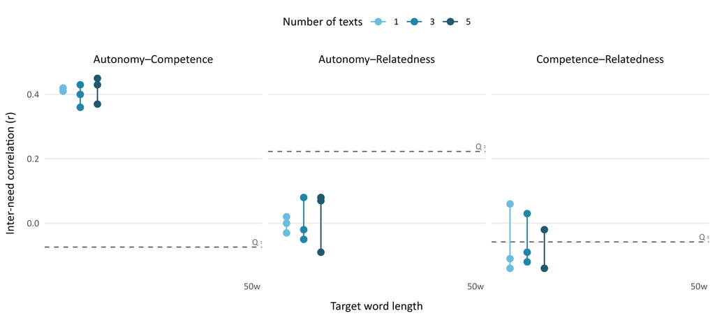

Figure 3: *H1d: LLM Inter-Need Correlations vs. Questionnaire Reference (Pearson r).* *Each panel shows one need pair. Lines and points = LLM r per condition,* *colored by number of texts (light to dark = 1, 3, 5). Dashed line = constant* *questionnaire r. Convergence toward the dashed line indicates structural consistency.*

# 5 Spearman Robustness Checks

## 5.1 H1c (Spearman): Discriminant Validity

Same analysis as Section 3 with Spearman ρ substituted for Pearson r in all three correlation inputs (`r_within`, `r_cross`, `r_y1y2`). Steiger’s (1980) test is designed for Pearson r; applying it to Spearman ρ is an approximation and results should be interpreted accordingly.

| condition | llm_dim | comparison | rho_within | rho_cross | diff | ci_lo | ci_hi | steiger_z | p_value | n |
| --- | --- | --- | --- | --- | --- | --- | --- | --- | --- | --- |
| 1 texts × 50w | llm_aut_mean | Q_Aut vs Q_Com | -0.05 | -0.004 | -0.050 | -0.19 | 0.09 | -0.66 | 0.506 | 394 |
| 1 texts × 50w | llm_aut_mean | Q_Aut vs Q_Rel | -0.05 | 0.024 | -0.078 | -0.21 | 0.06 | -1.16 | 0.245 | 394 |
| 1 texts × 50w | llm_com_mean | Q_Com vs Q_Aut | 0.10 | 0.114 | -0.011 | -0.15 | 0.13 | -0.15 | 0.879 | 394 |
| 1 texts × 50w | llm_com_mean | Q_Com vs Q_Rel | 0.10 | -0.016 | 0.119 | -0.02 | 0.25 | 1.61 | 0.108 | 394 |
| 1 texts × 50w | llm_rel_mean | Q_Rel vs Q_Aut | 0.03 | -0.016 | 0.050 | -0.09 | 0.19 | 0.74 | 0.457 | 394 |
| 1 texts × 50w | llm_rel_mean | Q_Rel vs Q_Com | 0.03 | 0.033 | 0.001 | -0.14 | 0.14 | 0.01 | 0.991 | 394 |
| 1 texts × 150w | llm_aut_mean | Q_Aut vs Q_Com | 0.12 | 0.055 | 0.068 | -0.07 | 0.21 | 0.91 | 0.363 | 394 |
| 1 texts × 150w | llm_aut_mean | Q_Aut vs Q_Rel | 0.12 | -0.015 | 0.138 | 0.00 | 0.27 | 2.07 | 0.038 | 394 |
| 1 texts × 150w | llm_com_mean | Q_Com vs Q_Aut | 0.10 | 0.126 | -0.028 | -0.17 | 0.11 | -0.38 | 0.704 | 394 |
| 1 texts × 150w | llm_com_mean | Q_Com vs Q_Rel | 0.10 | 0.044 | 0.054 | -0.09 | 0.19 | 0.73 | 0.465 | 394 |
| 1 texts × 150w | llm_rel_mean | Q_Rel vs Q_Aut | 0.04 | -0.034 | 0.071 | -0.07 | 0.21 | 1.06 | 0.290 | 394 |
| 1 texts × 150w | llm_rel_mean | Q_Rel vs Q_Com | 0.04 | -0.069 | 0.106 | -0.03 | 0.24 | 1.43 | 0.152 | 394 |
| 1 texts × 300w | llm_aut_mean | Q_Aut vs Q_Com | 0.14 | 0.085 | 0.052 | -0.09 | 0.19 | 0.71 | 0.481 | 394 |
| 1 texts × 300w | llm_aut_mean | Q_Aut vs Q_Rel | 0.14 | 0.117 | 0.020 | -0.12 | 0.16 | 0.31 | 0.756 | 394 |
| 1 texts × 300w | llm_com_mean | Q_Com vs Q_Aut | 0.13 | 0.201 | -0.076 | -0.22 | 0.06 | -1.04 | 0.300 | 394 |
| 1 texts × 300w | llm_com_mean | Q_Com vs Q_Rel | 0.13 | 0.007 | 0.118 | -0.02 | 0.25 | 1.60 | 0.109 | 394 |
| 1 texts × 300w | llm_rel_mean | Q_Rel vs Q_Aut | 0.11 | -0.036 | 0.145 | 0.01 | 0.28 | 2.18 | 0.029 | 394 |
| 1 texts × 300w | llm_rel_mean | Q_Rel vs Q_Com | 0.11 | -0.077 | 0.187 | 0.05 | 0.32 | 2.53 | 0.011 | 394 |
| 3 texts × 50w | llm_aut_mean | Q_Aut vs Q_Com | 0.06 | 0.011 | 0.050 | -0.09 | 0.19 | 0.67 | 0.506 | 394 |
| 3 texts × 50w | llm_aut_mean | Q_Aut vs Q_Rel | 0.06 | -0.001 | 0.061 | -0.08 | 0.20 | 0.91 | 0.360 | 394 |
| 3 texts × 50w | llm_com_mean | Q_Com vs Q_Aut | 0.05 | 0.071 | -0.020 | -0.16 | 0.12 | -0.27 | 0.787 | 394 |
| 3 texts × 50w | llm_com_mean | Q_Com vs Q_Rel | 0.05 | -0.062 | 0.113 | -0.03 | 0.25 | 1.52 | 0.128 | 394 |
| 3 texts × 50w | llm_rel_mean | Q_Rel vs Q_Aut | 0.12 | -0.023 | 0.141 | 0.00 | 0.27 | 2.11 | 0.034 | 394 |
| 3 texts × 50w | llm_rel_mean | Q_Rel vs Q_Com | 0.12 | -0.025 | 0.142 | 0.00 | 0.28 | 1.93 | 0.053 | 394 |
| 3 texts × 150w | llm_aut_mean | Q_Aut vs Q_Com | 0.02 | 0.068 | -0.051 | -0.19 | 0.09 | -0.68 | 0.497 | 394 |
| 3 texts × 150w | llm_aut_mean | Q_Aut vs Q_Rel | 0.02 | 0.106 | -0.089 | -0.23 | 0.05 | -1.34 | 0.180 | 394 |
| 3 texts × 150w | llm_com_mean | Q_Com vs Q_Aut | 0.14 | 0.115 | 0.022 | -0.12 | 0.16 | 0.29 | 0.770 | 394 |
| 3 texts × 150w | llm_com_mean | Q_Com vs Q_Rel | 0.14 | 0.025 | 0.112 | -0.03 | 0.25 | 1.53 | 0.126 | 394 |
| 3 texts × 150w | llm_rel_mean | Q_Rel vs Q_Aut | -0.07 | -0.117 | 0.047 | -0.09 | 0.19 | 0.72 | 0.474 | 394 |
| 3 texts × 150w | llm_rel_mean | Q_Rel vs Q_Com | -0.07 | -0.035 | -0.035 | -0.17 | 0.10 | -0.47 | 0.638 | 394 |
| 3 texts × 300w | llm_aut_mean | Q_Aut vs Q_Com | 0.08 | -0.024 | 0.102 | -0.04 | 0.24 | 1.36 | 0.174 | 394 |
| 3 texts × 300w | llm_aut_mean | Q_Aut vs Q_Rel | 0.08 | 0.064 | 0.014 | -0.13 | 0.15 | 0.21 | 0.832 | 394 |
| 3 texts × 300w | llm_com_mean | Q_Com vs Q_Aut | 0.10 | 0.144 | -0.040 | -0.18 | 0.10 | -0.54 | 0.592 | 394 |
| 3 texts × 300w | llm_com_mean | Q_Com vs Q_Rel | 0.10 | -0.010 | 0.115 | -0.02 | 0.25 | 1.56 | 0.120 | 394 |
| 3 texts × 300w | llm_rel_mean | Q_Rel vs Q_Aut | 0.03 | -0.020 | 0.052 | -0.09 | 0.19 | 0.77 | 0.440 | 394 |
| 3 texts × 300w | llm_rel_mean | Q_Rel vs Q_Com | 0.03 | -0.041 | 0.073 | -0.07 | 0.21 | 0.99 | 0.324 | 394 |
| 5 texts × 50w | llm_aut_mean | Q_Aut vs Q_Com | 0.06 | 0.073 | -0.009 | -0.15 | 0.13 | -0.11 | 0.909 | 394 |
| 5 texts × 50w | llm_aut_mean | Q_Aut vs Q_Rel | 0.06 | 0.123 | -0.059 | -0.20 | 0.08 | -0.89 | 0.376 | 394 |
| 5 texts × 50w | llm_com_mean | Q_Com vs Q_Aut | 0.10 | 0.115 | -0.015 | -0.15 | 0.12 | -0.20 | 0.841 | 394 |
| 5 texts × 50w | llm_com_mean | Q_Com vs Q_Rel | 0.10 | 0.025 | 0.076 | -0.06 | 0.21 | 1.03 | 0.304 | 394 |
| 5 texts × 50w | llm_rel_mean | Q_Rel vs Q_Aut | 0.00 | -0.039 | 0.035 | -0.10 | 0.17 | 0.53 | 0.599 | 394 |
| 5 texts × 50w | llm_rel_mean | Q_Rel vs Q_Com | 0.00 | -0.020 | 0.016 | -0.12 | 0.15 | 0.22 | 0.830 | 394 |
| 5 texts × 150w | llm_aut_mean | Q_Aut vs Q_Com | 0.10 | 0.045 | 0.057 | -0.08 | 0.20 | 0.77 | 0.444 | 394 |
| 5 texts × 150w | llm_aut_mean | Q_Aut vs Q_Rel | 0.10 | 0.096 | 0.006 | -0.13 | 0.15 | 0.09 | 0.928 | 394 |
| 5 texts × 150w | llm_com_mean | Q_Com vs Q_Aut | 0.09 | 0.148 | -0.059 | -0.20 | 0.08 | -0.80 | 0.424 | 394 |
| 5 texts × 150w | llm_com_mean | Q_Com vs Q_Rel | 0.09 | 0.047 | 0.042 | -0.10 | 0.18 | 0.57 | 0.572 | 394 |
| 5 texts × 150w | llm_rel_mean | Q_Rel vs Q_Aut | -0.07 | -0.033 | -0.034 | -0.17 | 0.11 | -0.51 | 0.608 | 394 |
| 5 texts × 150w | llm_rel_mean | Q_Rel vs Q_Com | -0.07 | -0.103 | 0.036 | -0.10 | 0.18 | 0.49 | 0.621 | 394 |
| 5 texts × 300w | llm_aut_mean | Q_Aut vs Q_Com | 0.11 | 0.025 | 0.088 | -0.05 | 0.22 | 1.18 | 0.239 | 394 |
| 5 texts × 300w | llm_aut_mean | Q_Aut vs Q_Rel | 0.11 | 0.068 | 0.045 | -0.09 | 0.18 | 0.68 | 0.497 | 394 |
| 5 texts × 300w | llm_com_mean | Q_Com vs Q_Aut | 0.11 | 0.094 | 0.020 | -0.12 | 0.16 | 0.27 | 0.785 | 394 |
| 5 texts × 300w | llm_com_mean | Q_Com vs Q_Rel | 0.11 | 0.033 | 0.081 | -0.06 | 0.22 | 1.11 | 0.269 | 394 |
| 5 texts × 300w | llm_rel_mean | Q_Rel vs Q_Aut | 0.06 | -0.066 | 0.125 | -0.01 | 0.26 | 1.88 | 0.060 | 394 |
| 5 texts × 300w | llm_rel_mean | Q_Rel vs Q_Com | 0.06 | -0.030 | 0.090 | -0.05 | 0.23 | 1.21 | 0.225 | 394 |

## 5.2 H1d (Spearman): Structural Consistency

Same analysis as Section 4 with Spearman ρ substituted for Pearson r for all six inter-need correlations. The meta-r between the two 3-element vectors remains Pearson (rank-ordering 3 values is not meaningful).

| condition | pair | rho_Q | rho_LLM | meta_r |
| --- | --- | --- | --- | --- |
| 1 texts × 50w | Aut-Com | -0.101 | 0.41 | -0.66 |
| 1 texts × 50w | Aut-Rel | 0.130 | 0.06 | -0.66 |
| 1 texts × 50w | Com-Rel | -0.070 | 0.09 | -0.66 |
| 1 texts × 150w | Aut-Com | -0.101 | 0.44 | -0.49 |
| 1 texts × 150w | Aut-Rel | 0.130 | -0.03 | -0.49 |
| 1 texts × 150w | Com-Rel | -0.070 | -0.11 | -0.49 |
| 1 texts × 300w | Aut-Com | -0.101 | 0.43 | -0.40 |
| 1 texts × 300w | Aut-Rel | 0.130 | 0.00 | -0.40 |
| 1 texts × 300w | Com-Rel | -0.070 | -0.14 | -0.40 |
| 3 texts × 50w | Aut-Com | -0.101 | 0.45 | -0.47 |
| 3 texts × 50w | Aut-Rel | 0.130 | 0.08 | -0.47 |
| 3 texts × 50w | Com-Rel | -0.070 | 0.00 | -0.47 |
| 3 texts × 150w | Aut-Com | -0.101 | 0.39 | -0.47 |
| 3 texts × 150w | Aut-Rel | 0.130 | -0.02 | -0.47 |
| 3 texts × 150w | Com-Rel | -0.070 | -0.10 | -0.47 |
| 3 texts × 300w | Aut-Com | -0.101 | 0.40 | -0.49 |
| 3 texts × 300w | Aut-Rel | 0.130 | -0.03 | -0.49 |
| 3 texts × 300w | Com-Rel | -0.070 | -0.10 | -0.49 |
| 5 texts × 50w | Aut-Com | -0.101 | 0.38 | -0.23 |
| 5 texts × 50w | Aut-Rel | 0.130 | 0.06 | -0.23 |
| 5 texts × 50w | Com-Rel | -0.070 | -0.16 | -0.23 |
| 5 texts × 150w | Aut-Com | -0.101 | 0.45 | -0.33 |
| 5 texts × 150w | Aut-Rel | 0.130 | 0.04 | -0.33 |
| 5 texts × 150w | Com-Rel | -0.070 | -0.15 | -0.33 |
| 5 texts × 300w | Aut-Com | -0.101 | 0.43 | -0.70 |
| 5 texts × 300w | Aut-Rel | 0.130 | -0.11 | -0.70 |
| 5 texts × 300w | Com-Rel | -0.070 | -0.03 | -0.70 |

# 6 Session Info